# P3 FAERS Database

Dominik Frei

21.3.2022 - 31.03.2022

# Abstract

Resources: I used this blogbost as reference to treat nested XML files: https://medium.com/geekculture/reading-xml-files-in-r-3122c3a2a8d9

What I learned:  
- Extracting data from nested XML files using xml2 package  
- Data manipulation using dplyr package  
- Setting up and importing data into MySQL database  
- Presenting code via R Markdown

Possible Improvement:  
- The function to convert XML to CSV was missing a part where the separator sign (here: “;”) used in the CSV would have been replaced in the data  
- The Tables in the created Database contain many columns. It might have made sense to set up more but smaller tables.

Duration:  
- MySQL: 13 h  
- R: 15 h  
- Other (writing/correcting text): 3.5 h

# Part 1

## R Script

Libraries and working directory

```r
library(xml2)
library(tidyverse)
```

```
Error : 'format_warning' is not an exported object from 'namespace:cli'
```

```r
setwd("C:/Users/domin/Desktop/Dominik/DS/Projects/P3_FAERS_DataBase")
```

Read one of the xml files and convert to list

```r
ADR21Q3_1 <- read_xml("FAERS_XML/XML/1_ADR21Q3.xml") %>% as_list()
```

This took very long, therefore I interrupted the process and created a smaller xml file by hand: I copied the data for the first three case reports in a new file and added “” at the end.

Try again with this file

```r
test <- read_xml("FAERS_XML/XML/test.xml") %>% as_list()
```

It worked

### Converting the XML File to CSV: First draft

Unnest and convert to tibble

```r
test_tb <- as_tibble(test) %>% unnest_longer('ichicsr')
head(test_tb)
```

```
# A tibble: 6 x 2
  ichicsr      ichicsr_id
  <named list> <chr>
1 <list [1]>   messagetype
2 <list [1]>   messageformatversion
3 <list [1]>   messageformatrelease
4 <list [1]>   messagenumb
5 <list [1]>   messagesenderidentifier
6 <list [1]>   messagereceiveridentifier
```

Before we go on we have to transform the data so that every record is a row and the ichicsr_id are the column names. Remove the metadata

```r
test_tb <- test_tb[9:74,]
head(test_tb)
```

```
# A tibble: 6 x 2
  ichicsr      ichicsr_id
  <named list> <chr>
1 <list [1]>   safetyreportversion
2 <list [1]>   safetyreportid
3 <list [1]>   primarysourcecountry
4 <list [1]>   occurcountry
5 <list [1]>   transmissiondateformat
6 <list [1]>   transmissiondate
```

Add a column with the report id, to make the records distinct from each other.

The first value in a record is the “safetyreportversion”.

```r
report_id <- test_tb[,"ichicsr_id"]
colnames(report_id) <- c("report_id")
ids <- test_tb[test_tb$ichicsr_id == "safetyreportid","ichicsr"] %>% unlist()

for (i in 1:nrow(test_tb)) {
        report_id[i,] <- ids[[(sum(i >= which(test_tb$ichicsr_id == "safetyreportversion")))]]
}

test_tb <- cbind(test_tb, report_id)
head(test_tb)
```

```
   ichicsr             ichicsr_id report_id
1        3    safetyreportversion  10097965
2 10097965         safetyreportid  10097965
3       DE   primarysourcecountry  10097965
4       DE           occurcountry  10097965
5      102 transmissiondateformat  10097965
6 20211014       transmissiondate  10097965
```

Pivot the data to get one row per record, use ichicsr as colnames

```r
test_tb_wider <- pivot_wider(test_tb,
                             names_from = "ichicsr_id",
                             values_from = "ichicsr",
                             values_fill = NA)
head(test_tb_wider[,1:5])
```

```
# A tibble: 3 x 5
  report_id safetyreportversion safetyreportid primarysourcecountry occurcountry
  <chr>     <named list>        <named list>   <named list>         <named list>
1 10097965  <list [1]>          <list [1]>     <list [1]>           <list [1]>
2 10287507  <list [1]>          <list [1]>     <list [1]>           <list [1]>
3 10303441  <list [1]>          <list [1]>     <list [1]>           <list [1]>
```

Now we have to unlist all the remaining nested elements (colums 18:22) (later we have to automate finding the still nested columns)

```r
test_df <- test_tb_wider

for (i in 1:5) {
        test_df <- test_df %>% unnest_wider(colnames(test_tb_wider[,(17+i)]))
}
```

There are more nested layers for drugs and reactions

We will separate those out and treat them separately

```r
for (i in 1:ncol(test_df)) {
        drugs <- test_df %>% colnames() %>% grep(pattern = "drug") %>% test_df[,.]
}

for (i in 1:ncol(test_df)) {
        reactions <- test_df %>% colnames() %>% grep(pattern = "reaction") %>% test_df[,.]
}
```

Now we will add a column with the case number to give them an id

```r
drugs <- cbind(report_id = test_df$report_id, drugs)
reactions <- cbind(report_id = test_df$report_id, reactions)
```

Pivot the data in order to make every drug/reaction a record

```r
drugs_longer <- drugs %>% pivot_longer(cols = 2:ncol(drugs))
reactions_longer <- reactions %>% pivot_longer(cols = 2:ncol(reactions))
```

Delete the records containing no data

```r
drugs_longer <- drugs_longer %>% filter(value != "NULL")
reactions_longer <- reactions_longer %>% filter(value != "NULL")
```

Add an index for each drug/reaction

```r
#drugs
drug_index <- list()
drugs_inds <- drugs_longer %>% group_by(report_id) %>% count()

for (i in 1:3) {
        n_rows <- drugs_inds[i,"n"] %>% as.integer()
        for (j in 1:n_rows) {
                drug_index <- append(drug_index, j)
        }
}

drugs_longer_ind <- drugs_longer %>% select(c("report_id", "value")) %>% cbind(., index = unlist(drug_index)) %>% select(report_id, index, value)

#reactions
reactions_index <- list()
reactions_inds <- reactions_longer %>% group_by(report_id) %>% count()

for (i in 1:3) {
        n_rows <- reactions_inds[i,"n"] %>% as.integer()
        for (j in 1:n_rows) {
                reactions_index <- append(reactions_index, j)
        }
}

reactions_longer_ind <- reactions_longer %>% select(c("report_id", "value")) %>% cbind(., index = unlist(reactions_index)) %>% select(report_id, index, value)
```

Unnest the value column (and expand the results to new columns) Then unnest the result, to have the real data; Unnest “activesubstance” column (for drugs data)

```r
#drugs
drugs_unnest <- drugs_longer_ind %>% unnest_wider(value)
drugs_unnest <- unnest(drugs_unnest, cols = colnames(drugs_unnest))
drugs_unnest <- unnest(drugs_unnest, cols = "activesubstance")

#reactions
reactions_unnest <- reactions_longer_ind %>% unnest_wider(value)
reactions_unnest <- unnest(reactions_unnest, cols = colnames(reactions_unnest))

head(drugs_unnest)
```

```
# A tibble: 6 x 22
  report_id index drugcharacteriz~ medicinalproduct drugbatchnumb
  <fct>     <int> <list>           <list>           <list>
1 10097965      1 <chr [1]>        <chr [1]>        <chr [1]>
2 10097965      2 <chr [1]>        <chr [1]>        <chr [1]>
3 10287507      1 <chr [1]>        <chr [1]>        <chr [1]>
4 10287507      2 <chr [1]>        <chr [1]>        <NULL>
5 10287507      3 <chr [1]>        <chr [1]>        <NULL>
6 10287507      4 <chr [1]>        <chr [1]>        <NULL>
# ... with 17 more variables: drugauthorizationnumb <list>,
#   drugadministrationroute <list>, drugindication <list>, actiondrug <list>,
#   drugadditional <list>, activesubstance <list>,
#   drugstructuredosagenumb <list>, drugstructuredosageunit <list>,
#   drugstartdateformat <list>, drugstartdate <list>,
#   drugseparatedosagenumb <list>, drugintervaldosageunitnumb <list>,
#   drugintervaldosagedefinition <list>, drugdosagetext <list>,
#   drugdosageform <list>, drugenddateformat <list>, drugenddate <list>
```

Clean up the remaining data (remove drug and reaction columns)

```r
exclude_dr <- test_df %>% colnames() %>% grep(pattern = 'drug|reaction') %>% test_df[,.] %>% colnames()
rest <- test_df %>% select(!exclude_dr)
```

Unnest the remaining nested variables (start with unnest_wider) for the variable that has another nested layer (summary)

```r
rest_unnest <- rest %>% unnest_wider(col = "summary") %>% unnest()
```

These dataframes (drugs_unnest, reactions_unnest, rest_unnest) would now be ready to be exported as csv and imported to MySQL.

### Refinement

Now we will try to automate all of it, put it into a function and try it on a bigger number of cases. I created a bigger file for testing (includes 50’000 lines of text) called test2.xml

```r
system.time(raw_data <- read_xml("FAERS_XML/XML/test2.xml") %>% as_list())
```

Import was relatively quick (8.22 seconds). raw_data contains 315 case reports. One of three files containing the case reports for one quarter contains 21 Mio. lines How many cases might the whole file contain?

```r
#around how many more cases are contained in one file
21000000/50000
```

```
[1] 420
```

```r
#around how many cases are contained in one file
420*315
```

```
[1] 132300
```

```r
#how long might the import take of such a file in minutes
8.22*420/60
```

```
[1] 57.54
```

Above I had mistakenly used unlist_longer. Now I used unlist_wider, which makes the transformations, I did right after that, obsolete. I also remove the metadata right here.

```r
raw_tb <- as_tibble(raw_data) %>% .[-c(1),"ichicsr"] %>% unnest_wider('ichicsr')
```

Note: this creates many columns and could become a problem with more data.

```r
to_exclude <- general %>% colnames() %>% grep(pattern = 'drug|reaction') %>% general[,.] %>% colnames()
general_clean <- general %>% select(!to_exclude)
```

Unnest everything

```r
general_unnest <- general_clean %>% unnest_wider(col = "summary") %>% unnest()
```

Drugs and reactions tables (not many changes to how it was done the first time)

```r
for (i in 1:ncol(general)) {
        drugs <- general %>% colnames() %>% grep(pattern = "drug") %>% general[,.]
}

for (i in 1:ncol(general)) {
        reactions <- general %>% colnames() %>% grep(pattern = "reaction") %>% general[,.]
}

#add the report id
drugs <- cbind(report_id = general_unnest[,"safetyreportid"], drugs)
reactions <- cbind(report_id = general_unnest[,"safetyreportid"], reactions)
#pivot
drugs_longer <- drugs %>% pivot_longer(cols = 2:ncol(drugs))
reactions_longer <- reactions %>% pivot_longer(cols = 2:ncol(reactions))
#delete
drugs_longer <- drugs_longer %>% filter(value != "NULL")
reactions_longer <- reactions_longer %>% filter(value != "NULL")
```

To assign an index for each record I now used apply() instead of a for loop.

```r
#drugs
indices <- function(length) {
        1:length
}

drugs_inds <- drugs_longer %>% group_by(safetyreportid) %>% count()
drug_index <- drugs_inds %>% ungroup() %>% select(n) %>% print() %>% apply(., 1, indices) %>% print()
drug_index <- drug_index %>% unlist()

drugs_longer_ind <- drugs_longer %>% cbind(., index = drug_index) %>% select(safetyreportid, index, value)

#reactions
reactions_inds <- reactions_longer %>% group_by(safetyreportid) %>% count()
reactions_index <- reactions_inds %>% ungroup() %>% select(n) %>% print() %>% apply(., 1, indices) %>% print()
reactions_index <- reactions_index %>% unlist()

reactions_longer_ind <- reactions_longer %>% cbind(., index = reactions_index) %>% select(safetyreportid, index, value)
```

Unnest everything (same as above); paste all drugrecurrence fields into one in order to avoid all the extra columns

```r
#drugs
drugs_unnest <- drugs_longer_ind %>% unnest_wider(value)
drugs_unnest <- unnest(drugs_unnest, cols = colnames(drugs_unnest))
drugs_unnest <- unnest(drugs_unnest, cols = "activesubstance")

#paste all drugrecurrence fields into one
selection <- drugs_unnest %>% colnames() %>% grep(pattern = 'drugrecurrence') %>% drugs_unnest[,.] %>% colnames()
selection_unnest <- selection %>% drugs_unnest[,.] %>% unnest(keep_empty = TRUE)
drugrecurrence <- selection_unnest %>% apply(., MARGIN = 1, FUN = paste, collapse = "; ") %>% print()
drugrecurrence[drugrecurrence == "NULL; NULL; NULL; NULL; NULL; NULL; NULL; NULL; NULL; NULL; NULL"] <- "NULL"
drugs_unnest <- drugs_unnest %>% select(!selection) %>% cbind(.,drugrecurrence)

#reactions
reactions_unnest <- reactions_longer_ind %>% unnest_wider(value)
reactions_unnest <- unnest(reactions_unnest, cols = colnames(reactions_unnest))
```

Write csv files

```r
general_unnest <- apply(general_unnest,2,as.character)
general_unnest %>% write.csv(.,file = "test2_general.csv")

drugs_unnest <- apply(drugs_unnest,2,as.character)
drugs_unnest %>% write.csv(.,file = "test2_drugs.csv")

reactions_unnest <- apply(reactions_unnest,2,as.character)
reactions_unnest %>% write.csv(.,file = "test2_reactions.csv")
```

### Final Function

Write one complete function from the above including everything except the reading and saving as list.

```r
E2b_xml_csv <- function(xml_list, name) {
        raw_tb <- as_tibble(xml_list) %>% .[-c(1),"ichicsr"] %>% unnest_wider('ichicsr')

        nested_cols <- c("reportduplicate", "primarysource", "sender", "receiver", "patient")
        general <- raw_tb

        for (i in 1:5) {
                general <- general %>% unnest_wider(col = nested_cols[i])
        }

        to_exclude <- general %>% colnames() %>% grep(pattern = 'drug|reaction') %>% general[,.] %>% colnames()
        general_clean <- general %>% select(!to_exclude)

        general_unnest <- general_clean %>% unnest_wider(col = "summary") %>% unnest()

        for (i in 1:ncol(general)) {
                drugs <- general %>% colnames() %>% grep(pattern = "drug") %>% general[,.]
        }

        for (i in 1:ncol(general)) {
                reactions <- general %>% colnames() %>% grep(pattern = "reaction") %>% general[,.]
        }

        #add the report id
        drugs <- cbind(report_id = general_unnest[,"safetyreportid"], drugs)
        reactions <- cbind(report_id = general_unnest[,"safetyreportid"], reactions)
        #pivot
        drugs_longer <- drugs %>% pivot_longer(cols = 2:ncol(drugs))
        reactions_longer <- reactions %>% pivot_longer(cols = 2:ncol(reactions))
        #delete
        drugs_longer <- drugs_longer %>% filter(value != "NULL")
        reactions_longer <- reactions_longer %>% filter(value != "NULL")

        #drugs
        indices <- function(length) {
                1:length
        }

        drugs_inds <- drugs_longer %>% group_by(safetyreportid) %>% count()
        drug_index <- drugs_inds %>% ungroup() %>% select(n) %>% print() %>% apply(., 1, indices) %>% print()
        drug_index <- drug_index %>% unlist()

        drugs_longer_ind <- drugs_longer %>% cbind(., index = drug_index) %>% select(safetyreportid, index, value)

        #reactions
        reactions_inds <- reactions_longer %>% group_by(safetyreportid) %>% count()
        reactions_index <- reactions_inds %>% ungroup() %>% select(n) %>% print() %>% apply(., 1, indices) %>% print()
        reactions_index <- reactions_index %>% unlist()

        reactions_longer_ind <- reactions_longer %>% cbind(., index = reactions_index) %>% select(safetyreportid, index, value)

        #unnest everything
        #drugs
        drugs_unnest <- drugs_longer_ind %>% unnest_wider(value)
        drugs_unnest <- unnest(drugs_unnest, cols = colnames(drugs_unnest))
        drugs_unnest <- unnest(drugs_unnest, cols = "activesubstance")

        #paste all drugrecurrence fields into one
        selection <- drugs_unnest %>% colnames() %>% grep(pattern = 'drugrecurrence') %>% drugs_unnest[,.] %>% colnames()
        selection_unnest <- selection %>% drugs_unnest[,.] %>% unnest(keep_empty = TRUE)
        drugrecurrence <- selection_unnest %>% apply(., MARGIN = 1, FUN = paste, collapse = ", ") %>% print()
        drugrecurrence[drugrecurrence == "NULL, NULL, NULL, NULL, NULL, NULL, NULL, NULL, NULL, NULL, NULL"] <- "NULL"
        drugs_unnest <- drugs_unnest %>% select(!selection) %>% cbind(.,drugrecurrence)

        #reactions
        reactions_unnest <- reactions_longer_ind %>% unnest_wider(value)
        reactions_unnest <- unnest(reactions_unnest, cols = colnames(reactions_unnest))

        #write csv
        general_unnest <- apply(general_unnest,2,as.character)
        file_name <- paste(name, "_general.csv", sep = "")
        general_unnest %>% write.table(.,file = file_name, row.names = FALSE, quote = FALSE, sep = ";")

        drugs_unnest <- apply(drugs_unnest,2,as.character)
        file_name <- paste(name, "_drugs.csv", sep = "")
        drugs_unnest %>% write.table(.,file = file_name, row.names = FALSE, quote = FALSE, sep = ";")

        reactions_unnest <- apply(reactions_unnest,2,as.character)
        file_name <- paste(name, "_reactions.csv", sep = "")
        reactions_unnest %>% write.table(.,file = file_name, row.names = FALSE, quote = FALSE, sep = ";")
}
```

What is still lacking here is to replace all “;” signs (used as separator in the csv file) in any of the data, to avoid problems with reading it into SQL.

Test it: Read in data again

```r
system.time(raw_data <- read_xml("FAERS_XML/XML/test2.xml") %>% as_list())
```

Run function

```r
system.time(E2b_xml_csv(raw_data, "test2"))
```

It took 16 seconds

How long will it take to treat the big file?

```r
16*420/60
```

```
[1] 112
```

### Lookup Tables

We also have to build the lookup tables for the database, as some of the data is coded.

I will include the following variables:

general:  
-reporttype  
-serious  
-qualification  
-patientonsetageunit  
-patientagegroup

drugs:  
-drugcharacterization  
-drugadministrationroute: big list => done via Excel  
-actiondrug  
-drugstructuredosageunit => done via Excel  
-drugintervaldosagedefinition => done via Excel

reactions:  
-reactionoutcome

The information for this is available in the document “XML_NTS” provided by the FDA and the ICH_ICSR_Specification_V2-3

reporttype

```r
lu_reporttype <- data.frame(reporttype = c(1,2,3,4), reporttype_def = c("Spontaneous", "Report from Study", "Other", "Not available to sender (unknown)"))
```

serious

```r
lu_serious <- data.frame(serious = c(1,2), serious_def = c("yes", "no"))
```

qualification

```r
lu_qualification <- data.frame(qualification = c(1,2,3,4,5),
                               qualification_def = c("Physician", "Pharmacist", "Other Health Professional", "Lawyer", "Consumer or non-health professional"))
```

patientonsetageunit

```r
lu_patientonsetageunit <- data.frame(patientonsetageunit = c(800,801,802,803,804,805),
                                patientonsetageunit_def = c("Decade", "Year", "Month", "Week", "Day", "Hour"))
```

patientagegroup

```r
lu_patientagegroup <- data.frame(patientagegroup = c(1,2,3,4,5,6),
                                patientagegroup_def = c("Neonate", "Infant", "Child", "Adolescent", "Adult", "Elderly"))
```

drugcharacterization

```r
lu_drugcharacterization <- data.frame(drugcharacterization = c(1,2,3), drugcharacterization_def = c("suspect", "concomitant", "interacting"))
```

actiondrug

```r
lu_actiondrug <- data.frame(actiondrug = c(1,2,3,4,5,6),
                                actiondrug_def = c("Drug Withdrawn", "Dose reduced", "Dose Increased", "Dose not changed", "Unknown", "Not applicable"))
```

reactionoutcome

```r
lu_reactionoutcome <- data.frame(reactionoutcome = c(1,2,3,4,5,6),
                                reactionoutcome_def = c("recovered/resolved", "recovering/resolving", "not recovered/not resolved", "recovered/resolved with sequelae",  "fatal", "unknown"))
```

write csv files

```r
lu_table_names <- c("lu_reporttype", "lu_serious", "lu_qualification", "lu_patientonsetageunit", "lu_patientagegroup", "lu_drugcharacterization", "lu_actiondrug", "lu_reactionoutcome")

for (i in 1:8) {
        filename <- paste("lu_tables/", lu_table_names[i], ".csv", sep = "")
        print(filename)
        write.csv(x = mget(lu_table_names[i]), file = filename, row.names = FALSE, col.names = TRUE, quote = FALSE)
}
```

### Test

Try reading in big file

```r
system.time(ADR21Q3_1 <- read_xml("FAERS_XML/XML/1_ADR21Q3.xml") %>% as_list())
```

It took 2433 seconds

```r
2433/60
```

```
[1] 40.55
```

= ca. 40 min

Save the created list (so I dont have to have it in memory all the time)

```r
saveRDS(ADR21Q3_1, file = "ADR_lists/ADR21Q3_1")
#remove it from workspace
rm(ADR21Q3_1)
#load it in again
ADR21Q3_1 <- readRDS(file = "ADR_lists/ADR21Q3_1")
```

Treat the big file

```r
system.time(E2b_xml_csv(ADR21Q3_1, "ADR21Q3_1"))
```

I interrupted the process after ca 14 h. Above we had calculated that it should take more or less 2 h, with the assumption that it would scale linearly! So it seems to not do that.

Also I don’t really know how much of the total process had been done after 14 h. I could have put print statements into the function, after certain steps had been accomplished.

I wrote a SQL Script to create a data model and insert data from the output of this script (See SQL Script “P3_PharmacovigilanceData_1.sql”).

As a transformation of more data did not seem feasible I abondonned this route and try to load the untreated XML files into MySQL.

## MySQL Script

Is loading local data enabled?

```sql
SHOW GLOBAL VARIABLES LIKE 'local_infile';
SET GLOBAL local_infile = 'ON';
```

Dont run on strict mode

```sql
SET sql_mode = "";
```

Find working directory

```sql
SHOW VARIABLES LIKE "secure_file_priv";
```

Create tables and load in files created for testing (“test2_general”, " test2_drugs“,”test2_reactions") and all the look up tables.

Lookup tables

```sql
-- create table
CREATE TABLE lu_actiondrug (
    actiondrug INT NOT NULL PRIMARY KEY,
    actiondrug_def VARCHAR(20),
    INDEX `fk_drugs_actiondrug_idx` (actiondrug ASC)
);

-- load in data
load data infile "C:/ProgramData/MySQL/MySQL Server 8.0/Uploads/lu_actiondrug.csv"
INTO TABLE lu_actiondrug
FIELDS TERMINATED BY ','
ENCLOSED BY ""
LINES TERMINATED BY '\n'
IGNORE 1 LINES
(actiondrug, actiondrug_def);

SELECT * FROM faers.lu_actiondrug;

-- create table
DROP TABLE IF EXISTS lu_drugadministrationroute;
CREATE TABLE lu_drugadministrationroute (
    drugadministrationroute INT NOT NULL PRIMARY KEY,
    drugadministrationroute_def VARCHAR(50),
    INDEX `fk_drugs_drugadministrationroute_idx` (drugadministrationroute ASC)
);

-- load in data (here the values are separated by ";" maybe due to it having been created via Excel)
load data infile "C:/ProgramData/MySQL/MySQL Server 8.0/Uploads/lu_drugadministrationroute.csv"
INTO TABLE lu_drugadministrationroute
FIELDS TERMINATED BY ';'
ENCLOSED BY ""
LINES TERMINATED BY '\n'
IGNORE 1 LINES
(drugadministrationroute, drugadministrationroute_def);

SELECT * FROM faers.lu_drugadministrationroute;

-- create table
DROP TABLE IF EXISTS lu_drugcharacterization;
CREATE TABLE lu_drugcharacterization (
    drugcharacterization INT NOT NULL PRIMARY KEY,
    drugcharacterization_def VARCHAR(20),
    INDEX `fk_drugs_drugcharacterization_idx` (drugcharacterization ASC)
);

-- load in data
load data infile "C:/ProgramData/MySQL/MySQL Server 8.0/Uploads/lu_drugcharacterization.csv"
INTO TABLE lu_drugcharacterization
FIELDS TERMINATED BY ','
ENCLOSED BY ""
LINES TERMINATED BY '\n'
IGNORE 1 LINES
(drugcharacterization, drugcharacterization_def);

SELECT * FROM faers.lu_drugcharacterization;

-- create table (separated by ";")
DROP TABLE IF EXISTS lu_drugintervaldosagedefinition;
CREATE TABLE lu_drugintervaldosagedefinition (
    drugintervaldosagedefinition INT NOT NULL PRIMARY KEY,
    drugintervaldosagedefinition_def VARCHAR(20),
    INDEX `fk_drugs_drugintervaldosagedefinition_idx` (drugintervaldosagedefinition ASC)
);

-- load in data
load data infile "C:/ProgramData/MySQL/MySQL Server 8.0/Uploads/lu_drugintervaldosagedefinition.csv"
INTO TABLE lu_drugintervaldosagedefinition
FIELDS TERMINATED BY ';'
ENCLOSED BY ""
LINES TERMINATED BY '\n'
IGNORE 1 LINES
(drugintervaldosagedefinition, drugintervaldosagedefinition_def);

SELECT * FROM faers.lu_drugintervaldosagedefinition;

-- create table (separated by ";")
DROP TABLE IF EXISTS lu_drugstructuredosageunit;
CREATE TABLE lu_drugstructuredosageunit (
    drugstructuredosageunit INT NOT NULL PRIMARY KEY,
    drugstructuredosageunit_def VARCHAR(20),
    INDEX `fk_drugs_drugstructuredosageunit_idx` (drugstructuredosageunit ASC)
);

-- load in data
load data infile "C:/ProgramData/MySQL/MySQL Server 8.0/Uploads/lu_drugstructuredosageunit.csv"
INTO TABLE lu_drugstructuredosageunit
FIELDS TERMINATED BY ';'
ENCLOSED BY ""
LINES TERMINATED BY '\n'
IGNORE 1 LINES
(drugstructuredosageunit, drugstructuredosageunit_def);

SELECT * FROM faers.lu_drugstructuredosageunit;

-- create table
DROP TABLE IF EXISTS lu_patientagegroup;
CREATE TABLE lu_patientagegroup (
    patientagegroup INT NOT NULL PRIMARY KEY,
    patientagegroup_def VARCHAR(20),
    INDEX `fk_general_patientagegroup_idx` (patientagegroup ASC)
);

-- load in data
load data infile "C:/ProgramData/MySQL/MySQL Server 8.0/Uploads/lu_patientagegroup.csv"
INTO TABLE lu_patientagegroup
FIELDS TERMINATED BY ','
ENCLOSED BY ""
LINES TERMINATED BY '\n'
IGNORE 1 LINES
(patientagegroup, patientagegroup_def);

SELECT * FROM faers.lu_patientagegroup;

-- create table
DROP TABLE IF EXISTS lu_patientonsetageunit;
CREATE TABLE lu_patientonsetageunit (
    patientonsetageunit INT NOT NULL PRIMARY KEY,
    patientonsetageunit_def VARCHAR(20),
    INDEX `fk_general_patientonsetageunit_idx` (patientonsetageunit ASC)
);

-- load in data
load data infile "C:/ProgramData/MySQL/MySQL Server 8.0/Uploads/lu_patientonsetageunit.csv"
INTO TABLE lu_patientonsetageunit
FIELDS TERMINATED BY ','
ENCLOSED BY ""
LINES TERMINATED BY '\n'
IGNORE 1 LINES
(patientonsetageunit, patientonsetageunit_def);

SELECT * FROM faers.lu_patientonsetageunit;

-- create table
DROP TABLE IF EXISTS lu_qualification;
CREATE TABLE lu_qualification (
    qualification INT NOT NULL PRIMARY KEY,
    qualification_def VARCHAR(50),
    INDEX `fk_general_qualification_idx` (qualification ASC)
);

-- load in data
load data infile "C:/ProgramData/MySQL/MySQL Server 8.0/Uploads/lu_qualification.csv"
INTO TABLE lu_qualification
FIELDS TERMINATED BY ','
ENCLOSED BY ""
LINES TERMINATED BY '\n'
IGNORE 1 LINES
(qualification, qualification_def);

SELECT * FROM faers.lu_qualification;

-- create table
DROP TABLE IF EXISTS lu_reactionoutcome;
CREATE TABLE lu_reactionoutcome (
    reactionoutcome INT NOT NULL PRIMARY KEY,
    reactionoutcome_def VARCHAR(50),
    INDEX `fk_reactions_reactionoutcome_idx` (reactionoutcome ASC)
);

-- load in data
load data infile "C:/ProgramData/MySQL/MySQL Server 8.0/Uploads/lu_reactionoutcome.csv"
INTO TABLE lu_reactionoutcome
FIELDS TERMINATED BY ','
ENCLOSED BY ""
LINES TERMINATED BY '\n'
IGNORE 1 LINES
(reactionoutcome, reactionoutcome_def);

SELECT * FROM faers.lu_reactionoutcome;

-- create table
DROP TABLE IF EXISTS lu_reporttype;
CREATE TABLE lu_reporttype (
    reporttype INT NOT NULL PRIMARY KEY,
    reporttype_def VARCHAR(50),
    INDEX `fk_general_reporttype_idx` (reporttype ASC)
);

-- load in data
load data infile "C:/ProgramData/MySQL/MySQL Server 8.0/Uploads/lu_reporttype.csv"
INTO TABLE lu_reporttype
FIELDS TERMINATED BY ','
ENCLOSED BY ""
LINES TERMINATED BY '\n'
IGNORE 1 LINES
(reporttype, reporttype_def);

SELECT * FROM faers.lu_reporttype;

-- create table
DROP TABLE IF EXISTS lu_serious;
CREATE TABLE lu_serious (
    serious INT NOT NULL PRIMARY KEY,
    serious_def VARCHAR(10),
    INDEX `fk_general_serious_idx` (serious ASC)
);

-- load in data
load data infile "C:/ProgramData/MySQL/MySQL Server 8.0/Uploads/lu_serious.csv"
INTO TABLE lu_serious
FIELDS TERMINATED BY ','
ENCLOSED BY ""
LINES TERMINATED BY '\n'
IGNORE 1 LINES
(serious, serious_def);
```

Now the three big tables: reactions

```sql
-- create table
DROP TABLE IF EXISTS test2_reactions;
CREATE TABLE test2_reactions (
    safetyreportid INT,
    `index` INT, # as index is a reserved word for MySQL, we have to use ``
    reactionmeddraversionpt DOUBLE,
    reactionmeddrapt VARCHAR(100),
    reactionoutcome INT DEFAULT NULL,
    PRIMARY KEY (safetyreportid, `index`)
);

-- load in data
load data infile "C:/ProgramData/MySQL/MySQL Server 8.0/Uploads/test2_reactions.csv"
INTO TABLE test2_reactions
FIELDS TERMINATED BY ';'
ENCLOSED BY ""
LINES TERMINATED BY '\n'
IGNORE 1 LINES
(safetyreportid, `index`, reactionmeddraversionpt, reactionmeddrapt, reactionoutcome);
```

Some warnings: NULL was tranformed to 0 one field of reaction outcome contained a comma => this was corrected via using “;” as separator in the R function (already implemented in statement above)

While adding the foreign key constraints I came upon the problem, that because in some cases the NULL values where converted to 0 during the insert, it was unable to connect the value to the lookup table. This is because 0 is not defined in the lookup table.

Unfortunately I was unable to resolve the issue during the import of the data. Therefore we will just convert the 0s to NULLs in the respective columns and then add the foreign keys

```sql
UPDATE test2_reactions SET reactionoutcome = NULL WHERE reactionoutcome = 0;

ALTER TABLE test2_reactions
ADD CONSTRAINT fk_test2_reactions_reactionoutcome
FOREIGN KEY (reactionoutcome) REFERENCES lu_reactionoutcome(reactionoutcome);
```

Continue with drugs table

```sql
-- create table
DROP TABLE IF EXISTS test2_drugs;
CREATE TABLE test2_drugs (
        safetyreportid INT,
    `index` INT,
    drugcharacterization INT,
    medicinalproduct VARCHAR(50),
    drugbatchnumb VARCHAR(50),
    drugauthorizationnumb VARCHAR(50),
    drugadministrationroute INT NULL,
    drugindication VARCHAR(50),
    actiondrug INT NULL,
    drugadditional INT NULL,
    activesubstance VARCHAR(50),
    drugstructuredosagenumb INT NULL,
    drugstructuredosageunit INT NULL,
    drugstartdateformat INT NULL,
    drugstartdate VARCHAR(50),
    drugseparatedosagenumb INT NULL,
    drugintervaldosageunitnumb INT NULL,
    drugintervaldosagedefinition INT NULL,
    drugdosagetext VARCHAR(50),
    drugdosageform VARCHAR(50),
    drugenddateformat INT NULL,
    drugenddate VARCHAR(50),
    drugrecurreadministration INT NULL,
    drugcumulativedosagenumb DOUBLE NULL,
    drugcumulativedosageunit INT NULL,
    drugrecurrence VARCHAR(255),
    PRIMARY KEY (safetyreportid, `index`)
);

-- load in data
load data infile "C:/ProgramData/MySQL/MySQL Server 8.0/Uploads/test2_drugs.csv"
INTO TABLE test2_drugs
FIELDS TERMINATED BY ';'
ENCLOSED BY ""
LINES TERMINATED BY '\n'
IGNORE 1 LINES
(safetyreportid, `index`, drugcharacterization, medicinalproduct, drugbatchnumb, drugauthorizationnumb, drugadministrationroute, drugindication, actiondrug,
    drugadditional, activesubstance, drugstructuredosagenumb, drugstructuredosageunit, drugstartdateformat, drugstartdate, drugseparatedosagenumb,
    drugintervaldosageunitnumb, drugintervaldosagedefinition, drugdosagetext, drugdosageform, drugenddateformat, drugenddate, drugrecurreadministration,
    drugcumulativedosagenumb, drugcumulativedosageunit, drugrecurrence
);
```

There are some instances where a datafield contain ; which leads to problems => this would have to be corrected in the R Script

Transform 0s to null in the columns linked to lookup table

```sql
UPDATE test2_drugs SET actiondrug = NULL WHERE actiondrug = 0;
UPDATE test2_drugs SET drugadministrationroute = NULL WHERE drugadministrationroute = 0;
UPDATE test2_drugs SET drugcharacterization = NULL WHERE drugcharacterization = 0;
UPDATE test2_drugs SET drugintervaldosagedefinition = NULL WHERE drugintervaldosagedefinition = 0;
UPDATE test2_drugs SET drugstructuredosageunit = NULL WHERE drugstructuredosageunit = 0;
```

Add the foreign keys

```sql
ALTER TABLE test2_drugs
ADD CONSTRAINT fk_test2_drugs_actiondrug
FOREIGN KEY (actiondrug) REFERENCES lu_actiondrug(actiondrug);
```

This failed

```sql
SELECT distinct actiondrug FROM faers.test2_drugs;
```

There are values that is not defined in our lookup table (58) We will replace them with null and try again

```sql
UPDATE test2_drugs SET actiondrug = NULL WHERE actiondrug = 58;
```

It worked; this “wrong” value might have been introduced because a datafield in the respective record contained a “;”, which then leads to data being inserted into the wrong column.

```sql
ALTER TABLE test2_drugs
ADD CONSTRAINT fk_test2_drugs_drugadministrationroute
FOREIGN KEY (drugadministrationroute) REFERENCES lu_drugadministrationroute(drugadministrationroute);
```

Fails

```sql
SELECT distinct drugadministrationroute FROM faers.test2_drugs;
```

There are values that is not defined in our lookup table (125402) We will replace them with null and try again

```sql
UPDATE test2_drugs SET drugadministrationroute = NULL WHERE drugadministrationroute = 125402;
```

Now it worked

Add other foreign keys

```sql
ALTER TABLE test2_drugs
ADD CONSTRAINT fk_test2_drugs_drugcharacterization
FOREIGN KEY (drugcharacterization) REFERENCES lu_drugcharacterization(drugcharacterization);

ALTER TABLE test2_drugs
ADD CONSTRAINT fk_test2_drugs_drugintervaldosagedefinition
FOREIGN KEY (drugintervaldosagedefinition) REFERENCES lu_drugintervaldosagedefinition(drugintervaldosagedefinition);

ALTER TABLE test2_drugs
ADD CONSTRAINT fk_test2_drugs_drugstructuredosageunit
FOREIGN KEY (drugstructuredosageunit) REFERENCES lu_drugstructuredosageunit(drugstructuredosageunit);
```

Fails

```sql
SELECT distinct drugstructuredosageunit FROM faers.test2_drugs;
```

There are values that is not defined in our lookup table (45, 508) We will replace them with null and try again

```sql
UPDATE test2_drugs SET drugstructuredosageunit = NULL WHERE drugstructuredosageunit in (45, 508);
```

It worked

Now to the table: general

```sql
-- create table
DROP TABLE IF EXISTS test2_general;
CREATE TABLE test2_general (
    safetyreportversion INT NOT NULL,
    safetyreportid INT NOT NULL,
    primarysourcecountry VARCHAR(2),
    occurcountry VARCHAR(2),
    transmissiondateformat INT NOT NULL,
    transmissiondate VARCHAR(10),
    reporttype INT NOT NULL,
    serious INT NOT NULL ,
    seriousnessother INT NULL,
    receivedateformat INT NOT NULL,
    receivedate VARCHAR(10),
    receiptdateformat INT NOT NULL,
    receiptdate VARCHAR(10),
    fulfillexpeditecriteria INT NOT NULL,
    companynumb VARCHAR(50),
    `duplicate` INT NOT NULL,
    duplicatesource VARCHAR(50),
    duplicatenumb VARCHAR(50),
    reportercountry VARCHAR(2),
    qualification INT NULL,
    literaturereference VARCHAR(255),
    sendertype INT NOT NULL,
    senderorganization VARCHAR(50),
    receivertype INT NOT NULL,
    receiverorganization VARCHAR(10),
    patientonsetage INT NULL,
    patientonsetageunit INT NULL,
    patientsex INT NULL,
    patientweight INT NULL,
    narrativeincludeclinical VARCHAR(50),
    patientagegroup INT NULL,
    seriousnesshospitalization INT NULL,
    seriousnessdeath INT NULL,
    authoritynumb VARCHAR(50),
    seriousnessdisabling INT NULL,
    seriousnesslifethreatening INT NULL,
    PRIMARY KEY (safetyreportid)
);

-- load in data
load data infile "C:/ProgramData/MySQL/MySQL Server 8.0/Uploads/test2_general.csv"
INTO TABLE test2_general
FIELDS TERMINATED BY ';'
ENCLOSED BY ""
LINES TERMINATED BY '\n'
IGNORE 1 LINES
(safetyreportversion, safetyreportid, primarysourcecountry, occurcountry, transmissiondateformat, transmissiondate, reporttype,
    serious, seriousnessother, receivedateformat, receivedate, receiptdateformat, receiptdate, fulfillexpeditecriteria, companynumb,
    `duplicate`, duplicatesource, duplicatenumb, reportercountry, qualification, literaturereference, sendertype, senderorganization,
    receivertype, receiverorganization, patientonsetage, patientonsetageunit, patientsex, patientweight, narrativeincludeclinical, patientagegroup,
    seriousnesshospitalization, seriousnessdeath, authoritynumb, seriousnessdisabling, seriousnesslifethreatening
);

SELECT * FROM faers.test2_general;
```

Transform 0s to null in the columns linked to lookup table

```sql
UPDATE test2_general SET patientagegroup = NULL WHERE patientagegroup = 0;
UPDATE test2_general SET patientonsetageunit = NULL WHERE patientonsetageunit = 0;
UPDATE test2_general SET qualification = NULL WHERE qualification = 0;
UPDATE test2_general SET serious = NULL WHERE serious = 0;
UPDATE test2_general SET reporttype = NULL WHERE reporttype = 0;
```

Add the foreign keys

```sql
ALTER TABLE test2_general
ADD CONSTRAINT fk_test2_general_patientagegroup
FOREIGN KEY (patientagegroup) REFERENCES lu_patientagegroup(patientagegroup);

ALTER TABLE test2_general
ADD CONSTRAINT fk_test2_general_patientonsetageunit
FOREIGN KEY (patientonsetageunit) REFERENCES lu_patientonsetageunit(patientonsetageunit);

ALTER TABLE test2_general
ADD CONSTRAINT fk_test2_general_qualification
FOREIGN KEY (qualification) REFERENCES lu_qualification(qualification);

ALTER TABLE test2_general
ADD CONSTRAINT fk_test2_general_serious
FOREIGN KEY (serious) REFERENCES lu_serious(serious);

ALTER TABLE test2_general
ADD CONSTRAINT fk_test2_general_reporttype
FOREIGN KEY (reporttype) REFERENCES lu_reporttype(reporttype);
```

I used reverse engineer to access the EER for the created data model. I remarked that I had not added the foreign keys to test2_general in test2_drugs and test2_reactions, so I did this in the EER Viewer in the MySQL Workbench. I saved this database as faers_2 and exported an image of the data model.

# Part 2

## MySQL Script

I create a new schema and use the same table creation statements as in Part 1

```sql
CREATE DATABASE faers_3;
USE faers_3;
```

Is loading local data enabeled?

```sql
SHOW GLOBAL VARIABLES LIKE 'local_infile';
SET GLOBAL local_infile = 'ON';
```

Dont run on strict mode

```sql
SET sql_mode = "";
```

Create table and try loading in XML file

```sql
-- create table
DROP TABLE IF EXISTS `general`;
CREATE TABLE general (
    safetyreportversion INT NOT NULL,
    safetyreportid INT NOT NULL,
    primarysourcecountry VARCHAR(2),
    occurcountry VARCHAR(2),
    transmissiondateformat INT NOT NULL,
    transmissiondate VARCHAR(10),
    reporttype INT NOT NULL,
    serious INT NOT NULL ,
    seriousnessother INT NULL,
    receivedateformat INT NOT NULL,
    receivedate VARCHAR(10),
    receiptdateformat INT NOT NULL,
    receiptdate VARCHAR(10),
    fulfillexpeditecriteria INT NOT NULL,
    companynumb VARCHAR(100),
    `duplicate` INT NULL,
    duplicatesource VARCHAR(50),
    duplicatenumb VARCHAR(50),
    reportercountry VARCHAR(2),
    qualification INT NULL,
    literaturereference VARCHAR(255),
    sendertype INT NULL,
    senderorganization VARCHAR(50),
    receivertype INT NULL,
    receiverorganization VARCHAR(10),
    patientonsetage INT NULL,
    patientonsetageunit INT NULL,
    patientsex INT NULL,
    patientweight INT NULL,
    narrativeincludeclinical VARCHAR(50),
    patientagegroup INT NULL,
    seriousnesshospitalization INT NULL,
    seriousnessdeath INT NULL,
    authoritynumb VARCHAR(100),
    seriousnessdisabling INT NULL,
    seriousnesslifethreatening INT NULL,
    PRIMARY KEY (safetyreportid)
    #,FOREIGN KEY (patientagegroup) REFERENCES lu_patientagegroup(patientagegroup),
    #FOREIGN KEY (patientonsetageunit) REFERENCES lu_patientonsetageunit(patientonsetageunit),
    #FOREIGN KEY (qualification) REFERENCES lu_qualification(qualification),
    #FOREIGN KEY (serious) REFERENCES lu_serious(serious),
    #FOREIGN KEY (reporttype) REFERENCES lu_reporttype(reporttype)
);

LOAD XML LOCAL INFILE 'C:/ProgramData/MySQL/MySQL Server 8.0/Uploads/1_ADR21Q3.xml'
INTO TABLE `general`
ROWS IDENTIFIED BY '<safetyreport>';
```

works - takes ca. 30 seconds, ca 180 k records I made some adaptions to the create table statement of the first part in order to get rid of all error messages

How does this work with the drugs and reactions table?

```sql
CREATE TABLE reactions (
    safetyreportid INT,
    reactionmeddraversionpt DOUBLE,
    reactionmeddrapt VARCHAR(100),
    reactionoutcome INT DEFAULT NULL
    #,PRIMARY KEY (safetyreportid)
);
LOAD XML LOCAL INFILE 'C:/ProgramData/MySQL/MySQL Server 8.0/Uploads/1_ADR21Q3.xml'
INTO TABLE reactions
ROWS IDENTIFIED BY '<safetyreport>';
```

Only one record per report Makes sense as we spefify, that a new row stars at every

Specify new row with every

```sql
LOAD XML LOCAL INFILE 'C:/ProgramData/MySQL/MySQL Server 8.0/Uploads/1_ADR21Q3.xml'
INTO TABLE reactions
ROWS IDENTIFIED BY '<reaction>';
```

Now there is the problem, that we cannot use safetyreport as primary key, as there are several reports per id we have to use an auto increment ID as primary key

Try again with generated primary key

```sql
CREATE TABLE reactions (
    Reaction_id int NOT NULL AUTO_INCREMENT,
    safetyreportid INT,
    reactionmeddraversionpt DOUBLE,
    reactionmeddrapt VARCHAR(100),
    reactionoutcome INT DEFAULT NULL,
    PRIMARY KEY (Reaction_id)
);
```

I will now use the previously set up data model as basis to import data from the XMLs

### Lookup Tables

```sql
-- create table
DROP TABLE IF EXISTS lu_actiondrug;
CREATE TABLE lu_actiondrug (
    actiondrug INT NOT NULL PRIMARY KEY,
    actiondrug_def VARCHAR(20),
    INDEX `fk_drugs_actiondrug_idx` (actiondrug ASC)
);

-- load in data
load data infile "C:/ProgramData/MySQL/MySQL Server 8.0/Uploads/lu_actiondrug.csv"
INTO TABLE lu_actiondrug
FIELDS TERMINATED BY ','
ENCLOSED BY ""
LINES TERMINATED BY '\n'
IGNORE 1 LINES
(actiondrug, actiondrug_def);

SELECT * FROM faers.lu_actiondrug;

-- create table
DROP TABLE IF EXISTS lu_drugadministrationroute;
CREATE TABLE lu_drugadministrationroute (
    drugadministrationroute INT NOT NULL PRIMARY KEY,
    drugadministrationroute_def VARCHAR(50),
    INDEX `fk_drugs_drugadministrationroute_idx` (drugadministrationroute ASC)
);

-- load in data (here the values are separated by ";" maybe due to it having been created via Excel)
load data infile "C:/ProgramData/MySQL/MySQL Server 8.0/Uploads/lu_drugadministrationroute.csv"
INTO TABLE lu_drugadministrationroute
FIELDS TERMINATED BY ';'
ENCLOSED BY ""
LINES TERMINATED BY '\n'
IGNORE 1 LINES
(drugadministrationroute, drugadministrationroute_def);

SELECT * FROM faers.lu_drugadministrationroute;

-- create table
DROP TABLE IF EXISTS lu_drugcharacterization;
CREATE TABLE lu_drugcharacterization (
    drugcharacterization INT NOT NULL PRIMARY KEY,
    drugcharacterization_def VARCHAR(20),
    INDEX `fk_drugs_drugcharacterization_idx` (drugcharacterization ASC)
);

-- load in data
load data infile "C:/ProgramData/MySQL/MySQL Server 8.0/Uploads/lu_drugcharacterization.csv"
INTO TABLE lu_drugcharacterization
FIELDS TERMINATED BY ','
ENCLOSED BY ""
LINES TERMINATED BY '\n'
IGNORE 1 LINES
(drugcharacterization, drugcharacterization_def);

SELECT * FROM faers.lu_drugcharacterization;

-- create table (separated by ";")
DROP TABLE IF EXISTS lu_drugintervaldosagedefinition;
CREATE TABLE lu_drugintervaldosagedefinition (
    drugintervaldosagedefinition INT NOT NULL PRIMARY KEY,
    drugintervaldosagedefinition_def VARCHAR(20),
    INDEX `fk_drugs_drugintervaldosagedefinition_idx` (drugintervaldosagedefinition ASC)
);

-- load in data
load data infile "C:/ProgramData/MySQL/MySQL Server 8.0/Uploads/lu_drugintervaldosagedefinition.csv"
INTO TABLE lu_drugintervaldosagedefinition
FIELDS TERMINATED BY ';'
ENCLOSED BY ""
LINES TERMINATED BY '\n'
IGNORE 1 LINES
(drugintervaldosagedefinition, drugintervaldosagedefinition_def);

SELECT * FROM faers.lu_drugintervaldosagedefinition;

-- create table (separated by ";")
DROP TABLE IF EXISTS lu_drugstructuredosageunit;
CREATE TABLE lu_drugstructuredosageunit (
    drugstructuredosageunit INT NOT NULL PRIMARY KEY,
    drugstructuredosageunit_def VARCHAR(20),
    INDEX `fk_drugs_drugstructuredosageunit_idx` (drugstructuredosageunit ASC)
);

-- load in data
load data infile "C:/ProgramData/MySQL/MySQL Server 8.0/Uploads/lu_drugstructuredosageunit.csv"
INTO TABLE lu_drugstructuredosageunit
FIELDS TERMINATED BY ';'
ENCLOSED BY ""
LINES TERMINATED BY '\n'
IGNORE 1 LINES
(drugstructuredosageunit, drugstructuredosageunit_def);

SELECT * FROM faers.lu_drugstructuredosageunit;

-- create table
DROP TABLE IF EXISTS lu_patientagegroup;
CREATE TABLE lu_patientagegroup (
    patientagegroup INT NOT NULL PRIMARY KEY,
    patientagegroup_def VARCHAR(20),
    INDEX `fk_general_patientagegroup_idx` (patientagegroup ASC)
);

-- load in data
load data infile "C:/ProgramData/MySQL/MySQL Server 8.0/Uploads/lu_patientagegroup.csv"
INTO TABLE lu_patientagegroup
FIELDS TERMINATED BY ','
ENCLOSED BY ""
LINES TERMINATED BY '\n'
IGNORE 1 LINES
(patientagegroup, patientagegroup_def);

SELECT * FROM faers.lu_patientagegroup;

-- create table
DROP TABLE IF EXISTS lu_patientonsetageunit;
CREATE TABLE lu_patientonsetageunit (
    patientonsetageunit INT NOT NULL PRIMARY KEY,
    patientonsetageunit_def VARCHAR(20),
    INDEX `fk_general_patientonsetageunit_idx` (patientonsetageunit ASC)
);

-- load in data
load data infile "C:/ProgramData/MySQL/MySQL Server 8.0/Uploads/lu_patientonsetageunit.csv"
INTO TABLE lu_patientonsetageunit
FIELDS TERMINATED BY ','
ENCLOSED BY ""
LINES TERMINATED BY '\n'
IGNORE 1 LINES
(patientonsetageunit, patientonsetageunit_def);

SELECT * FROM faers.lu_patientonsetageunit;

-- create table
DROP TABLE IF EXISTS lu_qualification;
CREATE TABLE lu_qualification (
    qualification INT NOT NULL PRIMARY KEY,
    qualification_def VARCHAR(50),
    INDEX `fk_general_qualification_idx` (qualification ASC)
);

-- load in data
load data infile "C:/ProgramData/MySQL/MySQL Server 8.0/Uploads/lu_qualification.csv"
INTO TABLE lu_qualification
FIELDS TERMINATED BY ','
ENCLOSED BY ""
LINES TERMINATED BY '\n'
IGNORE 1 LINES
(qualification, qualification_def);

SELECT * FROM faers.lu_qualification;

-- create table
DROP TABLE IF EXISTS lu_reactionoutcome;
CREATE TABLE lu_reactionoutcome (
    reactionoutcome INT NOT NULL PRIMARY KEY,
    reactionoutcome_def VARCHAR(50),
    INDEX `fk_reactions_reactionoutcome_idx` (reactionoutcome ASC)
);

-- load in data
load data infile "C:/ProgramData/MySQL/MySQL Server 8.0/Uploads/lu_reactionoutcome.csv"
INTO TABLE lu_reactionoutcome
FIELDS TERMINATED BY ','
ENCLOSED BY ""
LINES TERMINATED BY '\n'
IGNORE 1 LINES
(reactionoutcome, reactionoutcome_def);

SELECT * FROM faers.lu_reactionoutcome;

-- create table
DROP TABLE IF EXISTS lu_reporttype;
CREATE TABLE lu_reporttype (
    reporttype INT NOT NULL PRIMARY KEY,
    reporttype_def VARCHAR(50),
    INDEX `fk_general_reporttype_idx` (reporttype ASC)
);

-- load in data
load data infile "C:/ProgramData/MySQL/MySQL Server 8.0/Uploads/lu_reporttype.csv"
INTO TABLE lu_reporttype
FIELDS TERMINATED BY ','
ENCLOSED BY ""
LINES TERMINATED BY '\n'
IGNORE 1 LINES
(reporttype, reporttype_def);

SELECT * FROM faers.lu_reporttype;

-- create table
DROP TABLE IF EXISTS lu_serious;
CREATE TABLE lu_serious (
    serious INT NOT NULL PRIMARY KEY,
    serious_def VARCHAR(10),
    INDEX `fk_general_serious_idx` (serious ASC)
);

-- load in data
load data infile "C:/ProgramData/MySQL/MySQL Server 8.0/Uploads/lu_serious.csv"
INTO TABLE lu_serious
FIELDS TERMINATED BY ','
ENCLOSED BY ""
LINES TERMINATED BY '\n'
IGNORE 1 LINES
(serious, serious_def);

SELECT * FROM faers.lu_serious;
```

### Other Tables (general, reactions, drugs)

Drugs table:

```sql
 -- create table
DROP TABLE IF EXISTS reactions;
CREATE TABLE reactions (
    Reaction_id int NOT NULL AUTO_INCREMENT,
    safetyreportid INT,
    reactionmeddraversionpt DOUBLE,
    reactionmeddrapt VARCHAR(100),
    reactionoutcome INT DEFAULT NULL,
    PRIMARY KEY (Reaction_id),
    FOREIGN KEY (reactionoutcome) REFERENCES lu_reactionoutcome(reactionoutcome),
    INDEX `fk_general_reactions_idx` (safetyreportid ASC)
);

-- insert data
LOAD XML LOCAL INFILE 'C:/ProgramData/MySQL/MySQL Server 8.0/Uploads/1_ADR21Q3.xml'
INTO TABLE reactions
ROWS IDENTIFIED BY '<reaction>';

DROP TABLE IF EXISTS drugs;
CREATE TABLE drugs (
    Drugs_id int NOT NULL AUTO_INCREMENT,
    safetyreportid INT,
    drugcharacterization INT,
    medicinalproduct VARCHAR(255),
    drugbatchnumb VARCHAR(50),
    drugauthorizationnumb VARCHAR(50),
    drugadministrationroute INT NULL,
    drugindication VARCHAR(100),
    actiondrug INT NULL,
    drugadditional INT NULL,
    activesubstance VARCHAR(50),
    drugstructuredosagenumb INT NULL,
    drugstructuredosageunit INT NULL,
    drugstartdateformat INT NULL,
    drugstartdate VARCHAR(50),
    drugseparatedosagenumb INT NULL,
    drugintervaldosageunitnumb INT NULL,
    drugintervaldosagedefinition INT NULL,
    drugdosagetext VARCHAR(255),
    drugdosageform VARCHAR(50),
    drugenddateformat INT NULL,
    drugenddate VARCHAR(50),
    drugrecurreadministration INT NULL,
    drugcumulativedosagenumb DOUBLE NULL,
    drugcumulativedosageunit INT NULL,
    drugrecurrence VARCHAR(255),
    PRIMARY KEY (Drugs_id),
    FOREIGN KEY (actiondrug) REFERENCES lu_actiondrug(actiondrug),
    FOREIGN KEY (drugadministrationroute) REFERENCES lu_drugadministrationroute(drugadministrationroute),
    FOREIGN KEY (drugcharacterization) REFERENCES lu_drugcharacterization(drugcharacterization),
    FOREIGN KEY (drugintervaldosagedefinition) REFERENCES lu_drugintervaldosagedefinition(drugintervaldosagedefinition),
    FOREIGN KEY (drugstructuredosageunit) REFERENCES lu_drugstructuredosageunit(drugstructuredosageunit),
    INDEX `fk_general_drugs_idx` (safetyreportid ASC)
);

LOAD XML LOCAL INFILE 'C:/ProgramData/MySQL/MySQL Server 8.0/Uploads/1_ADR21Q3.xml'
INTO TABLE drugs
ROWS IDENTIFIED BY '<drug>';
```

I got error 1206 and had to set the buffer it to a bigger value

```sql
show variables like '%storage_engine%';
SET GLOBAL innodb_buffer_pool_size=2147483648;
```

ca 780 k were imported 140 rows where skipped as the drugstructuredosageunit did fail the foreign key constraints these values are probably just wrong in the data.

I will just disable the foreig key check to insert the data

```sql
SHOW GLOBAL VARIABLES LIKE 'FOREIGN_KEY_CHECKS';
SET FOREIGN_KEY_CHECKS=0;
```

general table:

```sql
-- create table
DROP TABLE IF EXISTS `general`;
CREATE TABLE general (
    safetyreportversion INT NOT NULL,
    safetyreportid INT NOT NULL,
    primarysourcecountry VARCHAR(2),
    occurcountry VARCHAR(2),
    transmissiondateformat INT NOT NULL,
    transmissiondate VARCHAR(10),
    reporttype INT NOT NULL,
    serious INT NOT NULL ,
    seriousnessother INT NULL,
    receivedateformat INT NOT NULL,
    receivedate VARCHAR(10),
    receiptdateformat INT NOT NULL,
    receiptdate VARCHAR(10),
    fulfillexpeditecriteria INT NOT NULL,
    companynumb VARCHAR(100),
    `duplicate` INT NULL,
    duplicatesource VARCHAR(50),
    duplicatenumb VARCHAR(50),
    reportercountry VARCHAR(2),
    qualification INT NULL,
    literaturereference VARCHAR(255),
    sendertype INT NULL,
    senderorganization VARCHAR(50),
    receivertype INT NULL,
    receiverorganization VARCHAR(10),
    patientonsetage INT NULL,
    patientonsetageunit INT NULL,
    patientsex INT NULL,
    patientweight INT NULL,
    narrativeincludeclinical VARCHAR(50),
    patientagegroup INT NULL,
    seriousnesshospitalization INT NULL,
    seriousnessdeath INT NULL,
    authoritynumb VARCHAR(100),
    seriousnessdisabling INT NULL,
    seriousnesslifethreatening INT NULL,
    PRIMARY KEY (safetyreportid),
    FOREIGN KEY (patientagegroup) REFERENCES lu_patientagegroup(patientagegroup),
    FOREIGN KEY (patientonsetageunit) REFERENCES lu_patientonsetageunit(patientonsetageunit),
    FOREIGN KEY (qualification) REFERENCES lu_qualification(qualification),
    FOREIGN KEY (serious) REFERENCES lu_serious(serious),
    FOREIGN KEY (reporttype) REFERENCES lu_reporttype(reporttype),
    FOREIGN KEY (safetyreportid) REFERENCES reactions(safetyreportid),
    FOREIGN KEY (safetyreportid) REFERENCES drugs(safetyreportid)
);

-- insert data
LOAD XML LOCAL INFILE 'C:/ProgramData/MySQL/MySQL Server 8.0/Uploads/1_ADR21Q3.xml'
INTO TABLE `general`
ROWS IDENTIFIED BY '<safetyreport>';
```

Ca. 180 k imported; 80 skipped as constraints with drug(safetyreportid) where not met Those must be records without an associated drug => those probably would not be very usefull anyways

Here I disabled the foreign key check as well to import the data

The next step will be to insert more data => maybe for the last two years

### Finalized Statements for Other Tables

I added the report version to the tables reactions and drugs in order to be able to distinguish between entries from differnt caseversions

The primary keay of the general table was defined as safetyreportid and safetyreportversion so it is unique.

Final create table statements

```sql
DROP TABLE IF EXISTS reactions;
CREATE TABLE reactions (
    Reaction_id int NOT NULL AUTO_INCREMENT,
    safetyreportversion INT NOT NULL,
    safetyreportid INT,
    reactionmeddraversionpt DOUBLE,
    reactionmeddrapt VARCHAR(100),
    reactionoutcome INT DEFAULT NULL,
    PRIMARY KEY (Reaction_id),
    FOREIGN KEY (reactionoutcome) REFERENCES lu_reactionoutcome(reactionoutcome),
    INDEX `fk_general_reactions_idx` (safetyreportid, safetyreportversion ASC)
);

DROP TABLE IF EXISTS drugs;
CREATE TABLE drugs (
    Drugs_id int NOT NULL AUTO_INCREMENT,
    safetyreportversion INT NOT NULL,
    safetyreportid INT,
    drugcharacterization INT,
    medicinalproduct VARCHAR(255),
    drugbatchnumb VARCHAR(50),
    drugauthorizationnumb VARCHAR(50),
    drugadministrationroute INT NULL,
    drugindication VARCHAR(100),
    actiondrug INT NULL,
    drugadditional INT NULL,
    activesubstance VARCHAR(50),
    drugstructuredosagenumb INT NULL,
    drugstructuredosageunit INT NULL,
    drugstartdateformat INT NULL,
    drugstartdate VARCHAR(50),
    drugseparatedosagenumb INT NULL,
    drugintervaldosageunitnumb INT NULL,
    drugintervaldosagedefinition INT NULL,
    drugdosagetext VARCHAR(255),
    drugdosageform VARCHAR(50),
    drugenddateformat INT NULL,
    drugenddate VARCHAR(50),
    drugrecurreadministration INT NULL,
    drugcumulativedosagenumb DOUBLE NULL,
    drugcumulativedosageunit INT NULL,
    drugrecurrence VARCHAR(255),
    PRIMARY KEY (Drugs_id),
    FOREIGN KEY (actiondrug) REFERENCES lu_actiondrug(actiondrug),
    FOREIGN KEY (drugadministrationroute) REFERENCES lu_drugadministrationroute(drugadministrationroute),
    FOREIGN KEY (drugcharacterization) REFERENCES lu_drugcharacterization(drugcharacterization),
    FOREIGN KEY (drugintervaldosagedefinition) REFERENCES lu_drugintervaldosagedefinition(drugintervaldosagedefinition),
    FOREIGN KEY (drugstructuredosageunit) REFERENCES lu_drugstructuredosageunit(drugstructuredosageunit),
    INDEX `fk_general_drugs_idx` (safetyreportid, safetyreportversion ASC)
);

DROP TABLE IF EXISTS `general`;
CREATE TABLE general (
    safetyreportversion INT NOT NULL,
    safetyreportid INT NOT NULL,
    primarysourcecountry VARCHAR(2),
    occurcountry VARCHAR(2),
    transmissiondateformat INT NOT NULL,
    transmissiondate VARCHAR(10),
    reporttype INT NOT NULL,
    serious INT NOT NULL ,
    seriousnessother INT NULL,
    receivedateformat INT NOT NULL,
    receivedate VARCHAR(10),
    receiptdateformat INT NOT NULL,
    receiptdate VARCHAR(10),
    fulfillexpeditecriteria INT NOT NULL,
    companynumb VARCHAR(100),
    `duplicate` INT NULL,
    duplicatesource VARCHAR(50),
    duplicatenumb VARCHAR(50),
    reportercountry VARCHAR(2),
    qualification INT NULL,
    literaturereference VARCHAR(255),
    sendertype INT NULL,
    senderorganization VARCHAR(50),
    receivertype INT NULL,
    receiverorganization VARCHAR(10),
    patientonsetage INT NULL,
    patientonsetageunit INT NULL,
    patientsex INT NULL,
    patientweight INT NULL,
    narrativeincludeclinical VARCHAR(50),
    patientagegroup INT NULL,
    seriousnesshospitalization INT NULL,
    seriousnessdeath INT NULL,
    authoritynumb VARCHAR(100),
    seriousnessdisabling INT NULL,
    seriousnesslifethreatening INT NULL,
    PRIMARY KEY (safetyreportid, safetyreportversion),
    FOREIGN KEY (patientagegroup) REFERENCES lu_patientagegroup(patientagegroup),
    FOREIGN KEY (patientonsetageunit) REFERENCES lu_patientonsetageunit(patientonsetageunit),
    FOREIGN KEY (qualification) REFERENCES lu_qualification(qualification),
    FOREIGN KEY (serious) REFERENCES lu_serious(serious),
    FOREIGN KEY (reporttype) REFERENCES lu_reporttype(reporttype),
    FOREIGN KEY (safetyreportid, safetyreportversion) REFERENCES reactions(safetyreportid, safetyreportversion),
    FOREIGN KEY (safetyreportid, safetyreportversion) REFERENCES drugs(safetyreportid, safetyreportversion)
);
```

### Final Database Model

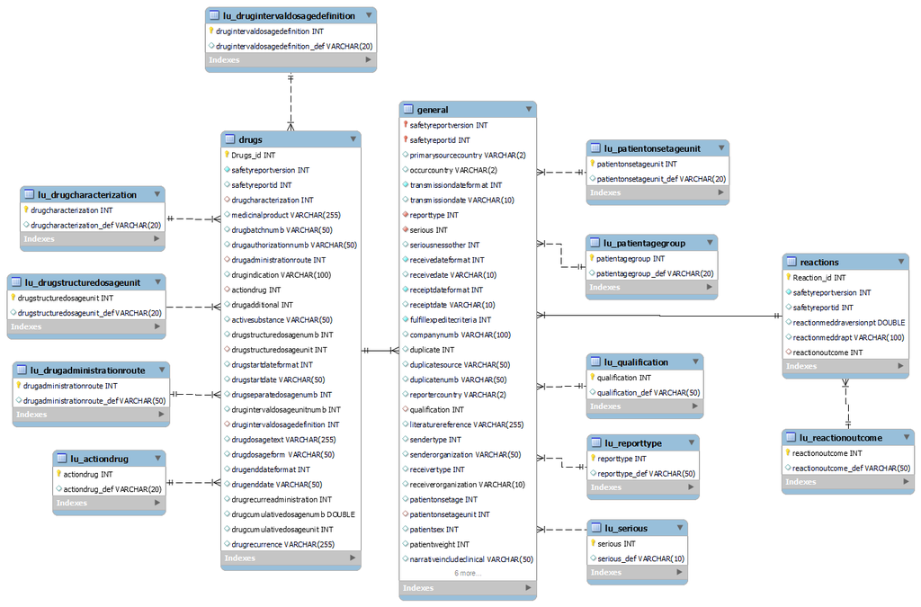

## R Script

As I was able to set up a database in which I can import the XML files provided by the FDA. I will now download more data (all files for the years 2021 and 2020), unzip them and write the insert statements for MySQL in this R Script.

Create the URLs to the files. The format is: https://fis.fda.gov/content/Exports/faers_xml_YYYYQQ.zip

```r
years <- c("2021", "2020")
quarters <- c("Q1", "Q2", "Q3", "Q4")
URLs <- list()
ids <- list()

for (i in 1:2) {
        for (j in 1:4) {
                id <- paste(years[i],
                            quarters[j],
                            sep = "")
                ids <- c(id, ids)

                URL <- paste("https://fis.fda.gov/content/Exports/faers_xml_",
                             id,
                             ".zip",
                             sep = "")
                URLs <- c(URL, URLs)
        }
}
```

Download the files

```r
for (i in 1:length(URLs)) {
        dest <- paste("FAERS_XML/files/",
                      ids[[i]],
                      ".zip",
                      sep = "")
        download.file(url = URLs[[i]],
                      destfile = dest)
}
```

Unzip the files

```r
for (i in 1:length(URLs)) {
        file <- paste("FAERS_XML/files/",
                      ids[[i]],
                      ".zip",
                      sep = "")
        directory <- "FAERS_XML/files/unziped"
        unzip(zipfile = file, exdir = directory, overwrite = TRUE)
}
```

Write the insert statements for MySQL:

table: “general”: LOAD XML LOCAL INFILE ‘C:/ProgramData/MySQL/MySQL Server 8.0/Uploads/X_ADRYYQQ.xml’ INTO TABLE `general` ROWS IDENTIFIED BY ‘’;

table: “drugs”: LOAD XML LOCAL INFILE ‘C:/ProgramData/MySQL/MySQL Server 8.0/Uploads/X_ADRYYQQ.xml’ INTO TABLE drugs ROWS IDENTIFIED BY ‘’;

table: “reactions”: LOAD XML LOCAL INFILE ‘C:/ProgramData/MySQL/MySQL Server 8.0/Uploads/X_ADRYYQQ.xml’ INTO TABLE reactions ROWS IDENTIFIED BY ‘’;

```r
#define necessary names for loop
table_names <- c("`general`", "drugs", "reactions")
identified_by <- c("'<safetyreport>'", "'<drug>'", "'<reaction>'")
file_numbers <- c("1", "2", "3")
years_short <- c("20", "21")
#quarters has already been defined

statements <- list()
outp <- list()

for (t in 1:3) {
        table <- table_names[[t]]
        identifyer <- identified_by[[t]]
        for (y in 1:2) {
                year <- years_short[[y]]
                for (f in 1:3) {
                        file <- file_numbers[[f]]
                        for (q in 1:4) {
                                quart <- quarters[[q]]
                                filename <- paste(file, "_ADR", year, quart, ".xml", sep = "")
                                statements <- c(statements, paste("LOAD XML LOCAL INFILE 'C:/ProgramData/MySQL/MySQL Server 8.0/Uploads/",
                                                                  filename,
                                                                  "'\n",
                                                                  "INTO TABLE ",
                                                                  table,
                                                                  "\nROWS IDENTIFIED BY ",
                                                                  identifyer,
                                                                  ";\n\n",
                                                                  sep = ""))


                        }

                }
        }

}

for (i in 1:length(statements)) {
        cat(statements[[i]])
}
```

The following insert statements where generated via the R Script above and ran successfully.

```sql
LOAD XML LOCAL INFILE 'C:/ProgramData/MySQL/MySQL Server 8.0/Uploads/1_ADR20Q1.xml'
INTO TABLE `general`
ROWS IDENTIFIED BY '<safetyreport>';

LOAD XML LOCAL INFILE 'C:/ProgramData/MySQL/MySQL Server 8.0/Uploads/1_ADR20Q2.xml'
INTO TABLE `general`
ROWS IDENTIFIED BY '<safetyreport>';

LOAD XML LOCAL INFILE 'C:/ProgramData/MySQL/MySQL Server 8.0/Uploads/1_ADR20Q3.xml'
INTO TABLE `general`
ROWS IDENTIFIED BY '<safetyreport>';

LOAD XML LOCAL INFILE 'C:/ProgramData/MySQL/MySQL Server 8.0/Uploads/1_ADR20Q4.xml'
INTO TABLE `general`
ROWS IDENTIFIED BY '<safetyreport>';

LOAD XML LOCAL INFILE 'C:/ProgramData/MySQL/MySQL Server 8.0/Uploads/2_ADR20Q1.xml'
INTO TABLE `general`
ROWS IDENTIFIED BY '<safetyreport>';

LOAD XML LOCAL INFILE 'C:/ProgramData/MySQL/MySQL Server 8.0/Uploads/2_ADR20Q2.xml'
INTO TABLE `general`
ROWS IDENTIFIED BY '<safetyreport>';

LOAD XML LOCAL INFILE 'C:/ProgramData/MySQL/MySQL Server 8.0/Uploads/2_ADR20Q3.xml'
INTO TABLE `general`
ROWS IDENTIFIED BY '<safetyreport>';

LOAD XML LOCAL INFILE 'C:/ProgramData/MySQL/MySQL Server 8.0/Uploads/2_ADR20Q4.xml'
INTO TABLE `general`
ROWS IDENTIFIED BY '<safetyreport>';

LOAD XML LOCAL INFILE 'C:/ProgramData/MySQL/MySQL Server 8.0/Uploads/3_ADR20Q1.xml'
INTO TABLE `general`
ROWS IDENTIFIED BY '<safetyreport>';

LOAD XML LOCAL INFILE 'C:/ProgramData/MySQL/MySQL Server 8.0/Uploads/3_ADR20Q2.xml'
INTO TABLE `general`
ROWS IDENTIFIED BY '<safetyreport>';

LOAD XML LOCAL INFILE 'C:/ProgramData/MySQL/MySQL Server 8.0/Uploads/3_ADR20Q3.xml'
INTO TABLE `general`
ROWS IDENTIFIED BY '<safetyreport>';

LOAD XML LOCAL INFILE 'C:/ProgramData/MySQL/MySQL Server 8.0/Uploads/3_ADR20Q4.xml'
INTO TABLE `general`
ROWS IDENTIFIED BY '<safetyreport>';

LOAD XML LOCAL INFILE 'C:/ProgramData/MySQL/MySQL Server 8.0/Uploads/1_ADR21Q1.xml'
INTO TABLE `general`
ROWS IDENTIFIED BY '<safetyreport>';

LOAD XML LOCAL INFILE 'C:/ProgramData/MySQL/MySQL Server 8.0/Uploads/1_ADR21Q2.xml'
INTO TABLE `general`
ROWS IDENTIFIED BY '<safetyreport>';

LOAD XML LOCAL INFILE 'C:/ProgramData/MySQL/MySQL Server 8.0/Uploads/1_ADR21Q3.xml'
INTO TABLE `general`
ROWS IDENTIFIED BY '<safetyreport>';

LOAD XML LOCAL INFILE 'C:/ProgramData/MySQL/MySQL Server 8.0/Uploads/1_ADR21Q4.xml'
INTO TABLE `general`
ROWS IDENTIFIED BY '<safetyreport>';

LOAD XML LOCAL INFILE 'C:/ProgramData/MySQL/MySQL Server 8.0/Uploads/2_ADR21Q1.xml'
INTO TABLE `general`
ROWS IDENTIFIED BY '<safetyreport>';

LOAD XML LOCAL INFILE 'C:/ProgramData/MySQL/MySQL Server 8.0/Uploads/2_ADR21Q2.xml'
INTO TABLE `general`
ROWS IDENTIFIED BY '<safetyreport>';

LOAD XML LOCAL INFILE 'C:/ProgramData/MySQL/MySQL Server 8.0/Uploads/2_ADR21Q3.xml'
INTO TABLE `general`
ROWS IDENTIFIED BY '<safetyreport>';

LOAD XML LOCAL INFILE 'C:/ProgramData/MySQL/MySQL Server 8.0/Uploads/2_ADR21Q4.xml'
INTO TABLE `general`
ROWS IDENTIFIED BY '<safetyreport>';

LOAD XML LOCAL INFILE 'C:/ProgramData/MySQL/MySQL Server 8.0/Uploads/3_ADR21Q1.xml'
INTO TABLE `general`
ROWS IDENTIFIED BY '<safetyreport>';

LOAD XML LOCAL INFILE 'C:/ProgramData/MySQL/MySQL Server 8.0/Uploads/3_ADR21Q2.xml'
INTO TABLE `general`
ROWS IDENTIFIED BY '<safetyreport>';

LOAD XML LOCAL INFILE 'C:/ProgramData/MySQL/MySQL Server 8.0/Uploads/3_ADR21Q3.xml'
INTO TABLE `general`
ROWS IDENTIFIED BY '<safetyreport>';

LOAD XML LOCAL INFILE 'C:/ProgramData/MySQL/MySQL Server 8.0/Uploads/3_ADR21Q4.xml'
INTO TABLE `general`
ROWS IDENTIFIED BY '<safetyreport>';

LOAD XML LOCAL INFILE 'C:/ProgramData/MySQL/MySQL Server 8.0/Uploads/1_ADR20Q1.xml'
INTO TABLE drugs
ROWS IDENTIFIED BY '<drug>';

LOAD XML LOCAL INFILE 'C:/ProgramData/MySQL/MySQL Server 8.0/Uploads/1_ADR20Q2.xml'
INTO TABLE drugs
ROWS IDENTIFIED BY '<drug>';

LOAD XML LOCAL INFILE 'C:/ProgramData/MySQL/MySQL Server 8.0/Uploads/1_ADR20Q3.xml'
INTO TABLE drugs
ROWS IDENTIFIED BY '<drug>';

LOAD XML LOCAL INFILE 'C:/ProgramData/MySQL/MySQL Server 8.0/Uploads/1_ADR20Q4.xml'
INTO TABLE drugs
ROWS IDENTIFIED BY '<drug>';

LOAD XML LOCAL INFILE 'C:/ProgramData/MySQL/MySQL Server 8.0/Uploads/2_ADR20Q1.xml'
INTO TABLE drugs
ROWS IDENTIFIED BY '<drug>';

LOAD XML LOCAL INFILE 'C:/ProgramData/MySQL/MySQL Server 8.0/Uploads/2_ADR20Q2.xml'
INTO TABLE drugs
ROWS IDENTIFIED BY '<drug>';

LOAD XML LOCAL INFILE 'C:/ProgramData/MySQL/MySQL Server 8.0/Uploads/2_ADR20Q3.xml'
INTO TABLE drugs
ROWS IDENTIFIED BY '<drug>';

LOAD XML LOCAL INFILE 'C:/ProgramData/MySQL/MySQL Server 8.0/Uploads/2_ADR20Q4.xml'
INTO TABLE drugs
ROWS IDENTIFIED BY '<drug>';

LOAD XML LOCAL INFILE 'C:/ProgramData/MySQL/MySQL Server 8.0/Uploads/3_ADR20Q1.xml'
INTO TABLE drugs
ROWS IDENTIFIED BY '<drug>';

LOAD XML LOCAL INFILE 'C:/ProgramData/MySQL/MySQL Server 8.0/Uploads/3_ADR20Q2.xml'
INTO TABLE drugs
ROWS IDENTIFIED BY '<drug>';

LOAD XML LOCAL INFILE 'C:/ProgramData/MySQL/MySQL Server 8.0/Uploads/3_ADR20Q3.xml'
INTO TABLE drugs
ROWS IDENTIFIED BY '<drug>';

LOAD XML LOCAL INFILE 'C:/ProgramData/MySQL/MySQL Server 8.0/Uploads/3_ADR20Q4.xml'
INTO TABLE drugs
ROWS IDENTIFIED BY '<drug>';

LOAD XML LOCAL INFILE 'C:/ProgramData/MySQL/MySQL Server 8.0/Uploads/1_ADR21Q1.xml'
INTO TABLE drugs
ROWS IDENTIFIED BY '<drug>';

LOAD XML LOCAL INFILE 'C:/ProgramData/MySQL/MySQL Server 8.0/Uploads/1_ADR21Q2.xml'
INTO TABLE drugs
ROWS IDENTIFIED BY '<drug>';

LOAD XML LOCAL INFILE 'C:/ProgramData/MySQL/MySQL Server 8.0/Uploads/1_ADR21Q3.xml'
INTO TABLE drugs
ROWS IDENTIFIED BY '<drug>';

LOAD XML LOCAL INFILE 'C:/ProgramData/MySQL/MySQL Server 8.0/Uploads/1_ADR21Q4.xml'
INTO TABLE drugs
ROWS IDENTIFIED BY '<drug>';

LOAD XML LOCAL INFILE 'C:/ProgramData/MySQL/MySQL Server 8.0/Uploads/2_ADR21Q1.xml'
INTO TABLE drugs
ROWS IDENTIFIED BY '<drug>';

LOAD XML LOCAL INFILE 'C:/ProgramData/MySQL/MySQL Server 8.0/Uploads/2_ADR21Q2.xml'
INTO TABLE drugs
ROWS IDENTIFIED BY '<drug>';

LOAD XML LOCAL INFILE 'C:/ProgramData/MySQL/MySQL Server 8.0/Uploads/2_ADR21Q3.xml'
INTO TABLE drugs
ROWS IDENTIFIED BY '<drug>';

LOAD XML LOCAL INFILE 'C:/ProgramData/MySQL/MySQL Server 8.0/Uploads/2_ADR21Q4.xml'
INTO TABLE drugs
ROWS IDENTIFIED BY '<drug>';

LOAD XML LOCAL INFILE 'C:/ProgramData/MySQL/MySQL Server 8.0/Uploads/3_ADR21Q1.xml'
INTO TABLE drugs
ROWS IDENTIFIED BY '<drug>';

LOAD XML LOCAL INFILE 'C:/ProgramData/MySQL/MySQL Server 8.0/Uploads/3_ADR21Q2.xml'
INTO TABLE drugs
ROWS IDENTIFIED BY '<drug>';

LOAD XML LOCAL INFILE 'C:/ProgramData/MySQL/MySQL Server 8.0/Uploads/3_ADR21Q3.xml'
INTO TABLE drugs
ROWS IDENTIFIED BY '<drug>';

LOAD XML LOCAL INFILE 'C:/ProgramData/MySQL/MySQL Server 8.0/Uploads/3_ADR21Q4.xml'
INTO TABLE drugs
ROWS IDENTIFIED BY '<drug>';

LOAD XML LOCAL INFILE 'C:/ProgramData/MySQL/MySQL Server 8.0/Uploads/1_ADR20Q1.xml'
INTO TABLE reactions
ROWS IDENTIFIED BY '<reaction>';

LOAD XML LOCAL INFILE 'C:/ProgramData/MySQL/MySQL Server 8.0/Uploads/1_ADR20Q2.xml'
INTO TABLE reactions
ROWS IDENTIFIED BY '<reaction>';

LOAD XML LOCAL INFILE 'C:/ProgramData/MySQL/MySQL Server 8.0/Uploads/1_ADR20Q3.xml'
INTO TABLE reactions
ROWS IDENTIFIED BY '<reaction>';

LOAD XML LOCAL INFILE 'C:/ProgramData/MySQL/MySQL Server 8.0/Uploads/1_ADR20Q4.xml'
INTO TABLE reactions
ROWS IDENTIFIED BY '<reaction>';

LOAD XML LOCAL INFILE 'C:/ProgramData/MySQL/MySQL Server 8.0/Uploads/2_ADR20Q1.xml'
INTO TABLE reactions
ROWS IDENTIFIED BY '<reaction>';

LOAD XML LOCAL INFILE 'C:/ProgramData/MySQL/MySQL Server 8.0/Uploads/2_ADR20Q2.xml'
INTO TABLE reactions
ROWS IDENTIFIED BY '<reaction>';

LOAD XML LOCAL INFILE 'C:/ProgramData/MySQL/MySQL Server 8.0/Uploads/2_ADR20Q3.xml'
INTO TABLE reactions
ROWS IDENTIFIED BY '<reaction>';

LOAD XML LOCAL INFILE 'C:/ProgramData/MySQL/MySQL Server 8.0/Uploads/2_ADR20Q4.xml'
INTO TABLE reactions
ROWS IDENTIFIED BY '<reaction>';

LOAD XML LOCAL INFILE 'C:/ProgramData/MySQL/MySQL Server 8.0/Uploads/3_ADR20Q1.xml'
INTO TABLE reactions
ROWS IDENTIFIED BY '<reaction>';

LOAD XML LOCAL INFILE 'C:/ProgramData/MySQL/MySQL Server 8.0/Uploads/3_ADR20Q2.xml'
INTO TABLE reactions
ROWS IDENTIFIED BY '<reaction>';

LOAD XML LOCAL INFILE 'C:/ProgramData/MySQL/MySQL Server 8.0/Uploads/3_ADR20Q3.xml'
INTO TABLE reactions
ROWS IDENTIFIED BY '<reaction>';

LOAD XML LOCAL INFILE 'C:/ProgramData/MySQL/MySQL Server 8.0/Uploads/3_ADR20Q4.xml'
INTO TABLE reactions
ROWS IDENTIFIED BY '<reaction>';

LOAD XML LOCAL INFILE 'C:/ProgramData/MySQL/MySQL Server 8.0/Uploads/1_ADR21Q1.xml'
INTO TABLE reactions
ROWS IDENTIFIED BY '<reaction>';

LOAD XML LOCAL INFILE 'C:/ProgramData/MySQL/MySQL Server 8.0/Uploads/1_ADR21Q2.xml'
INTO TABLE reactions
ROWS IDENTIFIED BY '<reaction>';

LOAD XML LOCAL INFILE 'C:/ProgramData/MySQL/MySQL Server 8.0/Uploads/1_ADR21Q3.xml'
INTO TABLE reactions
ROWS IDENTIFIED BY '<reaction>';

LOAD XML LOCAL INFILE 'C:/ProgramData/MySQL/MySQL Server 8.0/Uploads/1_ADR21Q4.xml'
INTO TABLE reactions
ROWS IDENTIFIED BY '<reaction>';

LOAD XML LOCAL INFILE 'C:/ProgramData/MySQL/MySQL Server 8.0/Uploads/2_ADR21Q1.xml'
INTO TABLE reactions
ROWS IDENTIFIED BY '<reaction>';

LOAD XML LOCAL INFILE 'C:/ProgramData/MySQL/MySQL Server 8.0/Uploads/2_ADR21Q2.xml'
INTO TABLE reactions
ROWS IDENTIFIED BY '<reaction>';

LOAD XML LOCAL INFILE 'C:/ProgramData/MySQL/MySQL Server 8.0/Uploads/2_ADR21Q3.xml'
INTO TABLE reactions
ROWS IDENTIFIED BY '<reaction>';

LOAD XML LOCAL INFILE 'C:/ProgramData/MySQL/MySQL Server 8.0/Uploads/2_ADR21Q4.xml'
INTO TABLE reactions
ROWS IDENTIFIED BY '<reaction>';

LOAD XML LOCAL INFILE 'C:/ProgramData/MySQL/MySQL Server 8.0/Uploads/3_ADR21Q1.xml'
INTO TABLE reactions
ROWS IDENTIFIED BY '<reaction>';

LOAD XML LOCAL INFILE 'C:/ProgramData/MySQL/MySQL Server 8.0/Uploads/3_ADR21Q2.xml'
INTO TABLE reactions
ROWS IDENTIFIED BY '<reaction>';

LOAD XML LOCAL INFILE 'C:/ProgramData/MySQL/MySQL Server 8.0/Uploads/3_ADR21Q3.xml'
INTO TABLE reactions
ROWS IDENTIFIED BY '<reaction>';

LOAD XML LOCAL INFILE 'C:/ProgramData/MySQL/MySQL Server 8.0/Uploads/3_ADR21Q4.xml'
INTO TABLE reactions
ROWS IDENTIFIED BY '<reaction>';
```

error messages: 1263 for reporttype receivedateformat (general) for 1/2/3_ADR21_Q4 I did not investigate this further.